# EDA 與建模報告：classification_wine.csv

任務：分類（多類別分類（3 類））｜目標：`cultivar`｜產生：2026-10-30 16:22｜遺失值：無｜最佳模型：Random Forest

**178**列數

**13**特徵數（數值 13 / 類別 0）

**無**遺失值

**Random Forest**最佳模型（依 CV）

**1.000**最佳模型測試 Accuracy

## 1. 資料與變數介紹

- **資料說明**：UCI 葡萄酒資料集（Forina et al.）：178 支產自義大利同一產區、由 3 個葡萄品種釀成的葡萄酒，依 13 項化學分析結果預測酒的品種（cultivar_1 / cultivar_2 / cultivar_3 各 59 / 71 / 48 支）。
- **分析目的（要預測什麼）**：預測 `cultivar`——葡萄品種（預測目標）：cultivar_1 / cultivar_2 / cultivar_3，共 3 類：cultivar_1（59 筆）、cultivar_2（71 筆）、cultivar_3（48 筆）。這是一個分類問題（判斷依據見第 2 節）。
- **用了哪些變數**：13 個特徵（數值 13、類別 0）——`alcohol`（酒精濃度，%）；`malic_acid`（蘋果酸）；`ash`（灰分）；`alcalinity_of_ash`（灰分鹼度）；`magnesium`（鎂）；`total_phenols`（總酚）；`flavanoids`（類黃酮）；`nonflavanoid_phenols`（非類黃酮酚）；`proanthocyanins`（原花青素）；`color_intensity`（色澤強度）；`hue`（色調）；`od280_od315`（稀釋酒液 OD280/OD315 吸光比（蛋白質含量指標））；`proline`（脯胺酸）。
- 資料共 **178 筆、14 個欄位**：目標 1 個（`cultivar`）、特徵 13 個（數值 13、類別 0）、ID／排除 0 個。
- 沒有 ID 類欄位，所有非目標欄位都當作特徵。
- 完全重複的列 0 筆；常數欄位 無。

### 變數與欄位介紹

| 欄位 | 說明 | 單位 | 角色 | 變數型態 | dtype | 遺失數 |
| --- | --- | --- | --- | --- | --- | --- |
| alcohol | 酒精濃度 | % | 特徵 | 數值 | float64 | 0 |
| malic_acid | 蘋果酸 | — | 特徵 | 數值 | float64 | 0 |
| ash | 灰分 | — | 特徵 | 數值 | float64 | 0 |
| alcalinity_of_ash | 灰分鹼度 | — | 特徵 | 數值 | float64 | 0 |
| magnesium | 鎂 | — | 特徵 | 數值 | float64 | 0 |
| total_phenols | 總酚 | — | 特徵 | 數值 | float64 | 0 |
| flavanoids | 類黃酮 | — | 特徵 | 數值 | float64 | 0 |
| nonflavanoid_phenols | 非類黃酮酚 | — | 特徵 | 數值 | float64 | 0 |
| proanthocyanins | 原花青素 | — | 特徵 | 數值 | float64 | 0 |
| color_intensity | 色澤強度 | — | 特徵 | 數值 | float64 | 0 |
| hue | 色調 | — | 特徵 | 數值 | float64 | 0 |
| od280_od315 | 稀釋酒液 OD280/OD315 吸光比（蛋白質含量指標） | — | 特徵 | 數值 | float64 | 0 |
| proline | 脯胺酸 | — | 特徵 | 數值 | float64 | 0 |
| cultivar | 葡萄品種（預測目標）：cultivar_1 / cultivar_2 / cultivar_3 | — | 目標 | 類別（標籤） | str | 0 |

## 2. 判斷任務類型（分類 or 迴歸）

- **判斷結果：分類（多類別分類（3 類））**。理由：目標是文字／布林值，代表「類別」而非數量。
- 多類別分類 = 預測「屬於哪一類」（超過兩類）；評估用 Accuracy、Macro-F1、混淆矩陣；切分要 stratify 保持各類別比例。
- 判斷規則：文字／布林 → 分類；只有 2 種值 → 二元分類；整數且 ≤10 種值 → 多類別分類（需確認是否為計數/評分）；其餘數值 → 迴歸。任務類型決定了之後的模型（Classifier vs Regressor）、評估指標與切分方式，所以是第一步。

### 任務類型判斷

| 檢查項目 | 結果 |
| --- | --- |
| 目標欄位 | cultivar |
| dtype | str |
| 是否為數值 | 否 |
| 是否全為整數 | 否 |
| 不同值個數 | 3 |
| 不同值佔比 | 1.69% |
| 範例值 | cultivar_1, cultivar_2, cultivar_3 |
| 判斷 | 分類：多類別分類（3 類） |

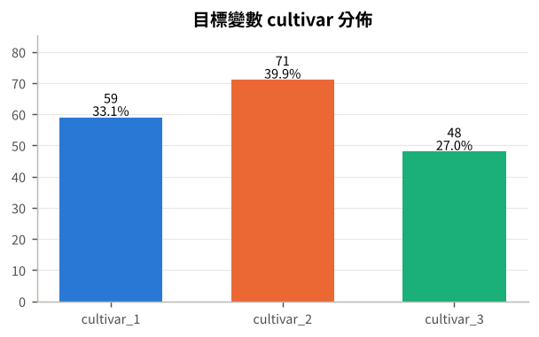

目標變數分佈：分類看各類別比例（是否不平衡）；迴歸看分佈形狀與偏態。

## 3. 敘述性統計

- 目標類別分佈：0=59（33.1%）, 1=71（39.9%）, 2=48（27.0%）。
- 偏態 |skew|>1 的欄位：malic_acid（1.03）、magnesium（1.09）。樹模型不受單調轉換影響，不必為了模型做 log；但線性模型或距離型插補（KNN）會受影響。
- 單變量與目標關係最強的特徵：flavanoids（η²(H)=0.73）、proline（η²(H)=0.67）、color_intensity（η²(H)=0.65）、alcohol（η²(H)=0.61）。這只是單變量篩選，交互作用與非線性要靠後面的模型。
- 高度相關（|ρ|>0.8）的特徵對共 1 對：total_phenols–flavanoids（0.88）。樹模型預測不受影響，但重要度會被兩者瓜分，解讀時要合併看；它們也是 MICE/KNN 插補的好幫手。

### 數值敘述統計

| 欄位 | 個數 | 遺失% | 平均數 | 標準差 | 最小值 | Q1 | 中位數 | Q3 | 最大值 | IQR | 變異係數CV | 偏態 | 峰態(超額) | 離群值數(1.5IQR) |
| --- | --- | --- | --- | --- | --- | --- | --- | --- | --- | --- | --- | --- | --- | --- |
| alcohol | 178 | 0 | 13 | 0.812 | 11.03 | 12.36 | 13.05 | 13.68 | 14.83 | 1.315 | 0.062 | -0.051 | -0.862 | 0 |
| malic_acid | 178 | 0 | 2.336 | 1.117 | 0.74 | 1.602 | 1.865 | 3.082 | 5.8 | 1.48 | 0.478 | 1.031 | 0.257 | 3 |
| ash | 178 | 0 | 2.367 | 0.274 | 1.36 | 2.21 | 2.36 | 2.558 | 3.23 | 0.348 | 0.116 | -0.175 | 1.079 | 3 |
| alcalinity_of_ash | 178 | 0 | 19.5 | 3.34 | 10.6 | 17.2 | 19.5 | 21.5 | 30 | 4.3 | 0.171 | 0.211 | 0.441 | 4 |
| magnesium | 178 | 0 | 99.74 | 14.28 | 70 | 88 | 98 | 107 | 162 | 19 | 0.143 | 1.089 | 2.013 | 4 |
| total_phenols | 178 | 0 | 2.295 | 0.626 | 0.98 | 1.742 | 2.355 | 2.8 | 3.88 | 1.057 | 0.273 | 0.086 | -0.846 | 0 |
| flavanoids | 178 | 0 | 2.029 | 0.999 | 0.34 | 1.205 | 2.135 | 2.875 | 5.08 | 1.67 | 0.492 | 0.025 | -0.889 | 0 |
| nonflavanoid_phenols | 178 | 0 | 0.362 | 0.124 | 0.13 | 0.27 | 0.34 | 0.438 | 0.66 | 0.167 | 0.344 | 0.446 | -0.653 | 0 |
| proanthocyanins | 178 | 0 | 1.591 | 0.572 | 0.41 | 1.25 | 1.555 | 1.95 | 3.58 | 0.7 | 0.36 | 0.513 | 0.506 | 2 |
| color_intensity | 178 | 0 | 5.058 | 2.318 | 1.28 | 3.22 | 4.69 | 6.2 | 13 | 2.98 | 0.458 | 0.861 | 0.337 | 4 |
| hue | 178 | 0 | 0.957 | 0.229 | 0.48 | 0.782 | 0.965 | 1.12 | 1.71 | 0.338 | 0.239 | 0.021 | -0.368 | 1 |
| od280_od315 | 178 | 0 | 2.612 | 0.71 | 1.27 | 1.938 | 2.78 | 3.17 | 4 | 1.232 | 0.272 | -0.305 | -1.09 | 0 |
| proline | 178 | 0 | 746.9 | 314.9 | 278 | 500.5 | 673.5 | 985 | 1,680 | 484.5 | 0.422 | 0.761 | -0.275 | 0 |

### 類別敘述統計

| 欄位 | 個數 | 遺失% | 類別數 | 眾數 | 眾數佔比% | 最少類別 | 最少類別佔比% | 各類別次數 |
| --- | --- | --- | --- | --- | --- | --- | --- | --- |
| cultivar | 178 | 0 | 3 | cultivar_2 | 39.89 | cultivar_3 | 26.97 | cultivar_2=71; cultivar_1=59; cultivar_3=48 |

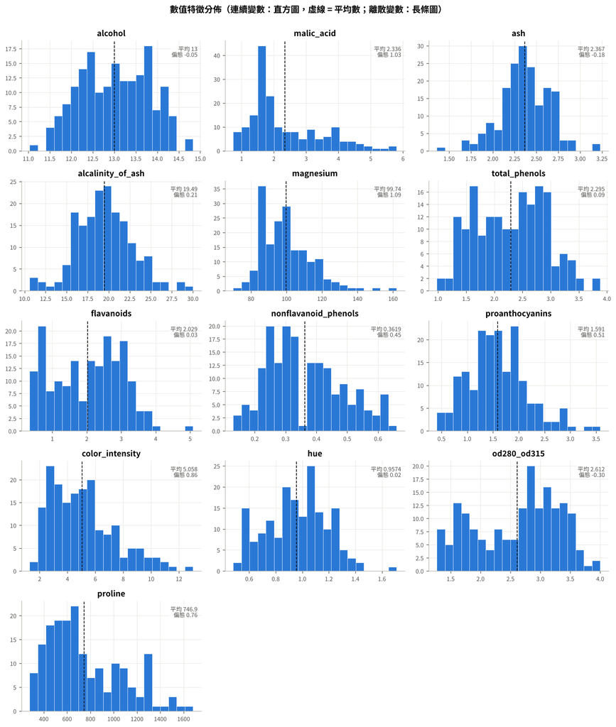

連續變數用直方圖（虛線為平均數），取值少的離散變數（如房間數、車位數）用長條圖；右上角為平均數與偏態。

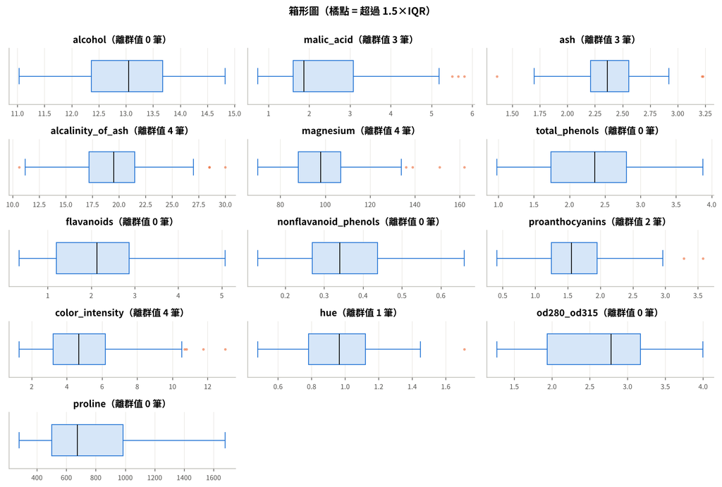

箱形圖：橘點為 1.5×IQR 外的離群值；樹模型對離群值穩健，但明顯的輸入錯誤仍應修正。

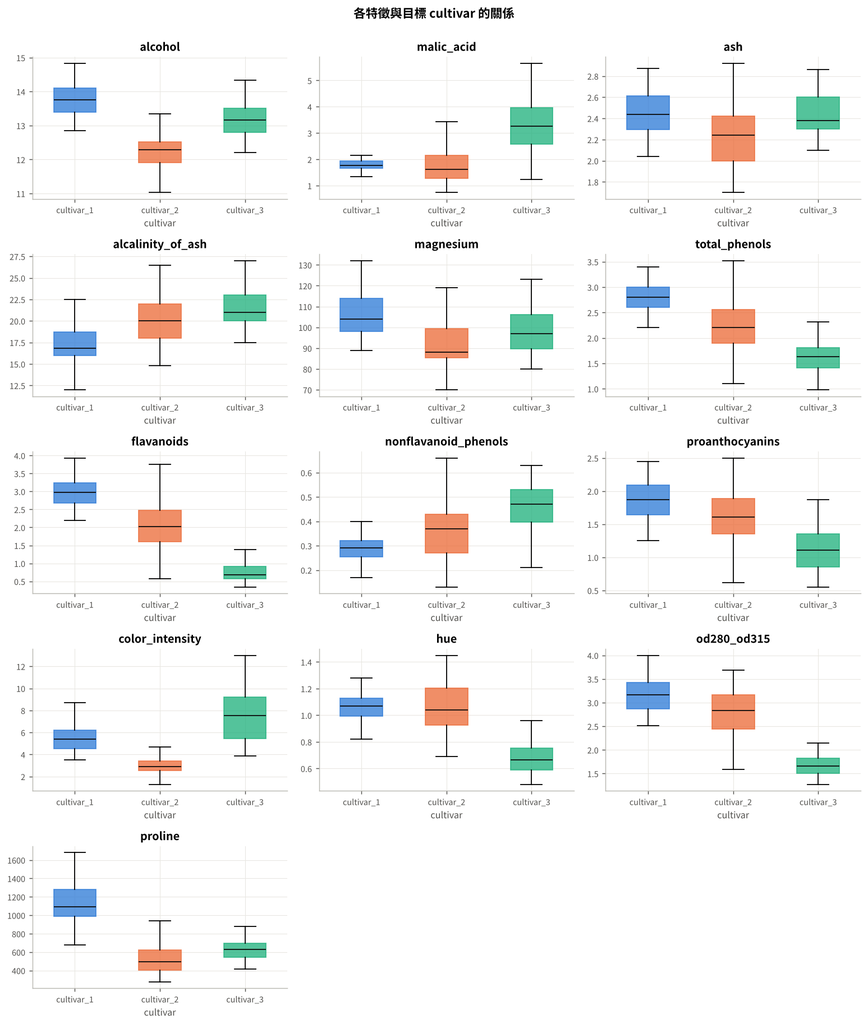

雙變量分析：分類看各類別的分佈差異或各水準的目標比率；迴歸看趨勢與非線性。

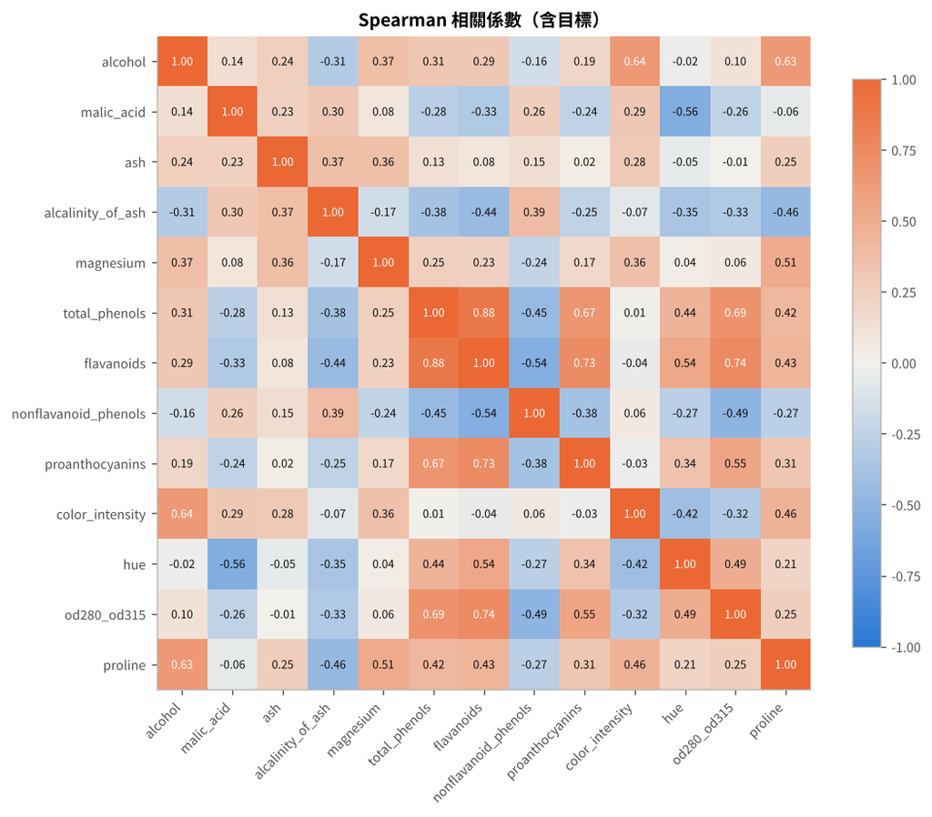

## 4. 遺失值檢查

- **沒有遺失值**：13 個特徵 × 178 筆資料都完整，**不需要做遺失值診斷與插補**，直接進入資料切分與建模。（遺失值的檢查仍必做——上線資料可能出現遺失，屆時再依本 skill 的遺失值流程處理。）

### 遺失值檢查

| 項目 | 結果 |
| --- | --- |
| 特徵欄位數 | 13 |
| 資料筆數 | 178 |
| 總格數 | 2,314 |
| 遺失格數 | 0（0.00%） |
| 有遺失的欄位數 | 0 |
| 完整列比例 | 100.0% |
| 判斷 | 無遺失 → 跳過遺失值診斷與處理 |

## 5. 資料切分

- **為什麼要切分**：模型在「看過的資料」上的分數一定偏樂觀（尤其是會記住資料的深樹）。必須留一份完全沒碰過的資料，才能估計上線後的真實表現。
- **本次做法**：先切出 25% 測試集（45 筆，鎖起來直到最後），剩下 133 筆訓練集再做 5 折交叉驗證（StratifiedKFold）：每次用 4 折訓練、1 折驗證，輪流 5 次取平均。模型用 CV 分數挑選，測試集只在最後報告一次。
- **分類要 stratify**：讓每份資料的類別比例都和全體相同，否則少數類別可能在某一份裡特別少，分數忽高忽低。
- 切分後各類別筆數（訓練 / 測試）：cultivar_1 44 / 15、cultivar_2 53 / 18、cultivar_3 36 / 12；合計 133 / 45。各類別在訓練、測試中的比例都和全體一致（stratify 的效果）。
- **避免洩漏**：插補、編碼、特徵選擇都放進 Pipeline，在每一折只用該折的訓練資料 fit；**不要**在切分前對全部資料算平均數補值或標準化。
- **其他切分情境**：有時間順序 → TimeSeriesSplit（只能用過去預測未來）；同一客戶/病人有多筆 → GroupKFold（同一群不能同時出現在訓練與驗證）；Boosting 的 early stopping → 再從訓練集切出一小份驗證集；資料很少 → 用重複 CV（RepeatedKFold）讓估計更穩。

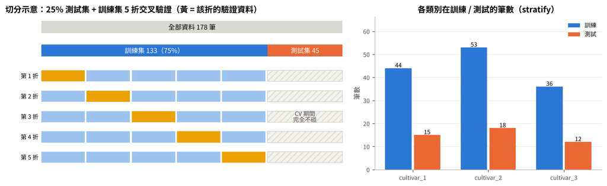

左：切分流程——測試集先鎖起來，訓練集內輪流用其中 1 折當驗證；右：檢查切分後目標分佈是否一致。

### 資料切分（各類別筆數）

| 類別 | 全部筆數 | 訓練筆數 | 測試筆數 | 訓練佔該類% | 測試佔該類% | 訓練集內佔比% | 測試集內佔比% |
| --- | --- | --- | --- | --- | --- | --- | --- |
| cultivar_1 | 59 | 44 | 15 | 74.6 | 25.4 | 33.1 | 33.3 |
| cultivar_2 | 71 | 53 | 18 | 74.6 | 25.4 | 39.8 | 40 |
| cultivar_3 | 48 | 36 | 12 | 75 | 25 | 27.1 | 26.7 |
| 合計 | 178 | 133 | 45 | 74.7 | 25.3 | 100 | 100 |

### 交叉驗證各折

| 折 | 訓練筆數 | 驗證筆數 | 驗證折 cultivar_1 筆數 | 驗證折 cultivar_2 筆數 | 驗證折 cultivar_3 筆數 |
| --- | --- | --- | --- | --- | --- |
| 1 | 106 | 27 | 9 | 11 | 7 |
| 2 | 106 | 27 | 9 | 11 | 7 |
| 3 | 106 | 27 | 9 | 10 | 8 |
| 4 | 107 | 26 | 9 | 10 | 7 |
| 5 | 107 | 26 | 8 | 11 | 7 |

## 6. 模型訓練與比較（分類）

- 比較三個樹模型：**Decision Tree**（單棵樹，可解釋）、**Random Forest**（多棵深樹平均，降方差）、**Gradient Boosting**（多棵淺樹接力修正殘差，降偏差）。三者使用相同的前處理 Pipeline 與相同的 CV 折，比較才公平。
- **調參方式**：每個樹模型都用 **GridSearchCV** 在訓練集上做 5 折交叉驗證，窮舉「模型參數與調參」表中的參數組合，選 CV Accuracy 最好的一組，再用整個訓練集重新訓練；最後只在測試集評估一次。註：調參後的 CV 分數因為是「挑過的最佳值」而略偏樂觀，所以最終以測試集確認。
- ⚠ 最佳參數落在搜尋範圍的邊界：Gradient Boosting 的 max_depth=2。代表更好的值可能在範圍外，實務上應擴大該參數的搜尋範圍再跑一次。
- 指標（多類別）：Accuracy（整體猜對比例，各類別筆數相同時最直觀，用來調參與選模型）、Macro-F1（各類別 F1 的平均，不受類別多寡影響）、AUC(ovr)（每一類對其他類的排序能力平均）。
- 依 CV 選出最佳模型 **Random Forest**：CV Accuracy 0.985±0.030，測試集 Accuracy 1.000（45 筆猜錯 0 筆）、Macro-F1 1.000。
- 訓練/測試 Accuracy 差距 0.000：過擬合可接受。
- 測試集只有 45 筆，猜錯 1 筆就差 0.022；多個模型分數接近時應視為平手，不要過度解讀。
- 置換重要度（測試集）前五名：proline（0.0600）、flavanoids（0.0533）、color_intensity（0.0356）、alcohol（0.0289）、hue（0.0267）。數值 = 打亂該欄後 Accuracy 變差多少；接近 0 或為負的欄位對模型幾乎沒貢獻。重要度不是因果。

### 模型參數與調參

| 模型 | 調參方式 | 搜尋範圍 | 最佳參數 | 固定參數 | 前處理 |
| --- | --- | --- | --- | --- | --- |
| Decision Tree | GridSearchCV（5 折 CV，24 組 × 5 折 = 120 次訓練） | max_depth ∈ [2, 3, 4, 5, 6, 8]；min_samples_leaf ∈ [1, 5, 10, 20] | max_depth=3、min_samples_leaf=1 | criterion=gini、random_state=42 | 數值直接輸入 |
| Random Forest | GridSearchCV（5 折 CV，9 組 × 5 折 = 45 次訓練） | max_features ∈ ['sqrt', 0.5, 1.0]；min_samples_leaf ∈ [1, 3, 5] | max_features=sqrt、min_samples_leaf=1 | n_estimators=300、bootstrap=True、random_state=42 | 數值直接輸入 |
| Gradient Boosting | GridSearchCV（5 折 CV，12 組 × 5 折 = 60 次訓練） | n_estimators ∈ [100, 300]；learning_rate ∈ [0.05, 0.1]；max_depth ∈ [2, 3, 4] | learning_rate=0.1、max_depth=2、n_estimators=300 | subsample=0.8、random_state=42 | 數值直接輸入 |

### 參數說明

| 參數 | 中文 | 意義與影響 |
| --- | --- | --- |
| max_depth | 最大深度 | 樹最多切幾層；越深越能擬合細節，但越容易過擬合（None = 不限制） |
| min_samples_leaf | 葉節點最少樣本數 | 每片葉子至少要有幾筆資料；越大越平滑、越不容易過擬合 |
| max_features | 每次分裂考慮的特徵比例 | RF 每個節點只從隨機抽出的特徵中找切點；越小樹之間越不相關（sqrt = √特徵數） |
| n_estimators | 樹的數量 | 集成中的樹數；RF 越多越穩定，Boosting 太多會過擬合（需搭配學習率） |
| learning_rate | 學習率 η | Boosting 每棵樹的貢獻縮放；越小越穩但需要更多樹 |
| subsample | 列抽樣比例 | 每棵樹只用部分資料訓練（隨機梯度提升），可降低過擬合 |

### 模型比較

| 模型 | 插補 | CV Accuracy | CV Accuracy 標準差 | 訓練 Accuracy | 測試 Accuracy | 測試 Macro-F1 | 測試 AUC(ovr) |
| --- | --- | --- | --- | --- | --- | --- | --- |
| Decision Tree | 無 | 0.9103 | 0.055 | 0.9925 | 0.9556 | 0.9565 | 0.9584 |
| Random Forest | 無 | 0.9852 | 0.0296 | 1 | 1 | 1 | 1 |
| Gradient Boosting | 無 | 0.9778 | 0.0296 | 1 | 0.9778 | 0.9797 | 1 |

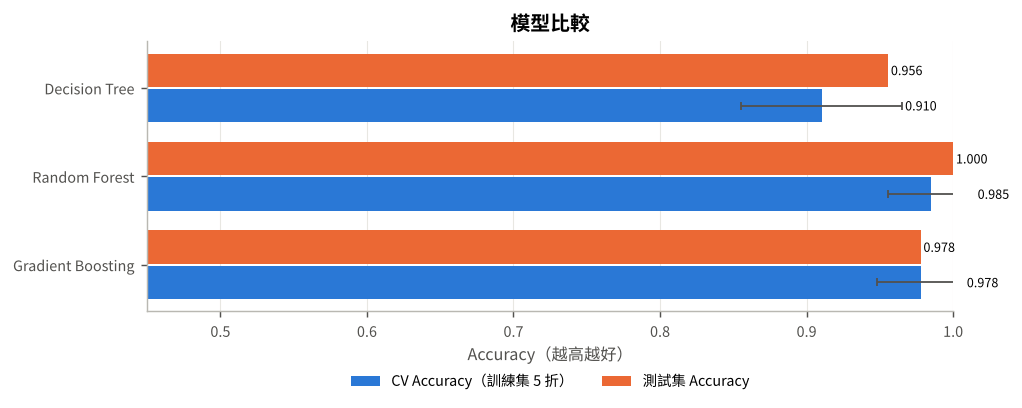

以 CV 選模型、測試集只做最終確認；誤差棒為 CV 標準差。

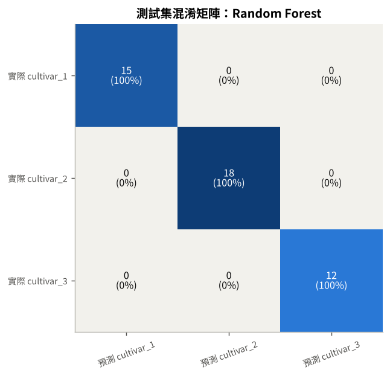

對角線 = 猜對；括號為該實際類別中被預測成各類的比例（每列加總 100%），可看出哪兩類容易混淆。

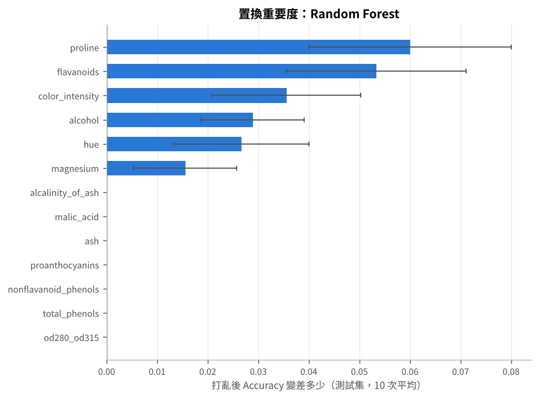

以原始欄位為單位計算（one-hot 與遺失指標一起算），比 impurity 重要度更不易被高基數 / 雜訊欄位騙。

所有表格另存於 descriptive_stats.xlsx；圖檔在 figures/。